# Predictive Modeling of Urban Micro-Mobility: A Case Study of New York City’s Bike-Share Ecosystem

Jane Le

2024-06-21

## Project Context & Background

In a bustling metropolis like New York City, transit isn’t just about subways and yellow cabs, but it’s about micro-mobility. Since its launch, the Citi Bike network has transformed from a novel experiment into a vital artery of NYC’s daily transportation ecosystem. However, running a massive bike-share network presents a chaotic logistical puzzle: on any given day, demand can wildly fluctuate based on a sudden downpour, a freezing winter morning, or a quiet holiday weekend.

When the weather changes or the city empties out for a long weekend, the entire flow of human traffic shifts. If operations teams cannot anticipate these shifts, bikes quickly stack up at the bottom of the city while high-demand transit hubs sit completely empty, leaving commuters stranded.

### The Goal of this Model

This project steps into the shoes of a city planner and operations strategist to understand the true heartbeat of the network. Rather than relying on operational guesswork, this model looks at historical patterns to answer a fundamental question: **How do the elements outside such as the weather in the sky and the calendar on the wall dictate how New Yorkers choose to move?**

By mapping these human behaviors, the model attempts to:

**Anticipate the City’s Pulse:** Understand exactly how much a rainy day or a major public holiday dampens the city’s urge to ride.

**Identify Weather Comfort Zones:** Discover the exact tipping points where rising temperatures stop encouraging riders and instead make physical commuting unappealing.

**Empower Proactive Logistics:** Provide a clear, reliable baseline of daily demand so fleet managers can move bikes to where they are needed most before the morning rush hour even begins.

```r
data_url <- "https://raw.githubusercontent.com/phuongjanele/citibike-model/main/trips_per_day.tsv"
#load tsv dataframe
trips_per_day <- read_tsv(data_url)
head(trips_per_day)
```

```
## # A tibble: 6 × 8
##   ymd        num_trips     date  prcp  snwd  snow  tmax  tmin
##   <date>         <dbl>    <dbl> <dbl> <dbl> <dbl> <dbl> <dbl>
## 1 2014-01-01      6059 20140101  0      0     0     3.3   2.4
## 2 2014-01-02      8600 20140102  0.33   0     3.1   3.3   1.8
## 3 2014-01-03      1144 20140103  0.29   5.9   3.3   1.8   0.9
## 4 2014-01-04      2292 20140104  0      5.9   0     2.9   0.8
## 5 2014-01-05      2678 20140105  0.14   3.9   0     4     2.7
## 6 2014-01-06      9510 20140106  0.36   1.2   0     5.5   1.9
```

```r
trips_per_day <- trips_per_day%>%
  mutate(weekday = wday(ymd,label=TRUE))%>%
  mutate(is_weekend = as.numeric(weekday%in%c('Sun', 'Sat')))%>%
   select(-weekday)
```

```r
holiday_data <- read.csv('holiday_data.csv')

# Rename columns
colnames(holiday_data) <- c("id", "ymd", "holiday_name")

# is_weekend feature is added as a column
holiday_dates <- (c("0101", "0102", "0115", "0116", "0117", "0118", "0119", "0120", "0121", "0215", "0216", "0217", "0218", "0219", "0220", "0525", "0526", "0527", "0528", "0529", "0530", "0703", "0704",  "0901", "0902", "0903", "0904", "0905", "0906", "0907", "1008", "1009", "1010", "1011", "1012", "1013", "1014", "1110", "1111", "1112", "1122", "1123", "1124", "1125", "1126", "1127", "1128", "1225"))

trips_per_day <- trips_per_day |>
  mutate(is_holiday = as.numeric(substr(date, 5, 8) %in% holiday_dates, 1, 0))
```

```r
#Splitting 90% data for training & validation, 10% for testing
set.seed(42)

# Assume trips_per_day is your data frame and it has already been loaded

num_days <- nrow(trips_per_day)
frac_train <- 0.7
frac_validation <- 0.2
frac_test <- 0.1
train_size <- floor(num_days * frac_train)
validation_size <- floor(num_days * frac_validation)
test_size <- num_days - train_size - validation_size

# Randomly sample rows for the training set

train_indices <- sample(1:num_days, train_size, replace = FALSE)

# Remaining indices after removing the training indices

remaining_indices <- setdiff(1:num_days, train_indices)

# Randomly sample rows for the validation set from the remaining indices

validation_indices <- sample(remaining_indices, validation_size, replace = FALSE)

# Remaining indices after removing the validation indices

test_indices <- setdiff(remaining_indices, validation_indices)

# Create the training, validation, and test sets

trips_per_day_train <- trips_per_day[train_indices, ]

trips_per_day_validation <- trips_per_day[validation_indices, ]

trips_per_day_test <- trips_per_day[test_indices, ]

# Check the sizes of each set to ensure correctness

cat("Training set size:", nrow(trips_per_day_train), "\n")
```

```
## Training set size: 255
```

```r
cat("Validation set size:", nrow(trips_per_day_validation), "\n")
```

```
## Validation set size: 73
```

```r
cat("Test set size:", nrow(trips_per_day_test), "\n")
```

```
## Test set size: 37
```

```r
regfit.full <- regsubsets(num_trips ~ ., trips_per_day_train)
summary(regfit.full)
```

```
## Subset selection object
## Call: regsubsets.formula(num_trips ~ ., trips_per_day_train)
## 9 Variables  (and intercept)
##            Forced in Forced out
## ymd            FALSE      FALSE
## date           FALSE      FALSE
## prcp           FALSE      FALSE
## snwd           FALSE      FALSE
## snow           FALSE      FALSE
## tmax           FALSE      FALSE
## tmin           FALSE      FALSE
## is_weekend     FALSE      FALSE
## is_holiday     FALSE      FALSE
## 1 subsets of each size up to 8
## Selection Algorithm: exhaustive
##          ymd date prcp snwd snow tmax tmin is_weekend is_holiday
## 1  ( 1 ) " " " "  " "  " "  " "  "*"  " "  " "        " "
## 2  ( 1 ) " " " "  "*"  " "  " "  "*"  " "  " "        " "
## 3  ( 1 ) " " " "  "*"  " "  " "  "*"  " "  "*"        " "
## 4  ( 1 ) " " " "  "*"  " "  " "  "*"  " "  "*"        "*"
## 5  ( 1 ) " " " "  "*"  "*"  " "  "*"  " "  "*"        "*"
## 6  ( 1 ) " " " "  "*"  "*"  " "  "*"  "*"  "*"        "*"
## 7  ( 1 ) "*" " "  "*"  "*"  " "  "*"  "*"  "*"        "*"
## 8  ( 1 ) "*" "*"  "*"  "*"  " "  "*"  "*"  "*"        "*"
```

```r
# create k var models based on the method above

cv.error.8 <- rep(0, 8)
one_var_model <- glm(num_trips ~ tmax, data = trips_per_day_train)
cv.error.8[1] <- cv.glm(trips_per_day_train, one_var_model, K = 10)$delta[1]

two_var_model <- glm(num_trips ~ prcp + tmax, data = trips_per_day_train)
cv.error.8[2] <- cv.glm(trips_per_day_train, two_var_model, K = 10)$delta[1]

three_var_model <- glm(num_trips ~is_weekend *(prcp + tmax), data = trips_per_day_train)
cv.error.8[3] <- cv.glm(trips_per_day_train, three_var_model, K = 10)$delta[1]

four_var_model <- glm(num_trips ~ is_weekend * is_holiday *(prcp + tmax), data = trips_per_day_train)
cv.error.8[4] <- cv.glm(trips_per_day_train, four_var_model, K = 10)$delta[1]

five_var_model <- glm(num_trips ~ is_weekend * is_holiday * (prcp + snwd + tmax), data = trips_per_day_train)
cv.error.8[5] <- cv.glm(trips_per_day_train, five_var_model, K = 10)$delta[1]

six_var_model <- glm(num_trips ~ is_weekend * is_holiday *(prcp + snwd + tmax + tmin), data = trips_per_day_train)
cv.error.8[6] <- cv.glm(trips_per_day_train, six_var_model, K = 10)$delta[1]

seven_var_model <- glm(num_trips ~ is_weekend * is_holiday * (date + prcp + snwd + tmax + tmin), data = trips_per_day_train)
cv.error.8[7] <- cv.glm(trips_per_day_train, seven_var_model, K = 10)$delta[1]

eight_var_model <- glm(num_trips ~ is_weekend * is_holiday *( date + prcp + snwd + snow + tmax + tmin), data = trips_per_day_train)

cv.error.8[8] <- cv.glm(trips_per_day_train, eight_var_model, K = 10)$delta[1]

cv.error.8
```

```
## [1]   32278724   24539822   18019473   18816549   17405482   19180034  255863706
## [8] 4160672829
```

```r
min(cv.error.8)# it seems like the 5-var method performs the best
```

```
## [1] 17405482
```

```r
#running polynomial degree on five_var_model
 cv.error <- rep(0, 10)
 for (i in 1:10) {
glm.fit <- glm(num_trips ~ is_weekend * (poly(tmax, i) + prcp + snwd + tmax + is_holiday), data = trips_per_day_train )
cv.error[i] <- cv.glm(trips_per_day_train, glm.fit)$delta[1]
}
cv.error
```

```
##  [1] 16801971 16939963 15307224 14294759 14442183 14711155 14917133 14391212
##  [9] 14525311 14803728
```

```r
#select 4th degree for five_var_model
min(cv.error)
```

```
## [1] 14294759
```

```r
# Selecting the fourth-degree polynomial model
best_degree <- which.min(cv.error)  # Find the degree with the minimum cross-validation error
formula <- as.formula(paste("num_trips ~ is_weekend * (poly(tmax, ", best_degree, ") + prcp + snwd + tmax + is_holiday)", sep = ""))
five_var_fourth_poly_model <- glm(formula, data = trips_per_day_train)

# Summary of the selected model
summary(five_var_fourth_poly_model)
```

```
##
## Call:
## glm(formula = formula, data = trips_per_day_train)
##
## Coefficients: (2 not defined because of singularities)
##                            Estimate Std. Error t value Pr(>|t|)
## (Intercept)                25428.88     329.14  77.258  < 2e-16 ***
## is_weekend                 -6250.36     664.53  -9.406  < 2e-16 ***
## poly(tmax, 4)1            135565.14    4836.70  28.028  < 2e-16 ***
## poly(tmax, 4)2             -2045.54    4478.04  -0.457 0.648234
## poly(tmax, 4)3            -19949.87    4090.81  -4.877 1.97e-06 ***
## poly(tmax, 4)4            -16782.44    4265.40  -3.935 0.000109 ***
## prcp                       -8795.58     867.47 -10.139  < 2e-16 ***
## snwd                        -341.32     121.75  -2.803 0.005472 **
## tmax                             NA         NA      NA       NA
## is_holiday                 -2876.22     789.78  -3.642 0.000332 ***
## is_weekend:poly(tmax, 4)1 -10282.01   12030.90  -0.855 0.393610
## is_weekend:poly(tmax, 4)2 -10911.71   13628.23  -0.801 0.424118
## is_weekend:poly(tmax, 4)3  -2258.51   13540.54  -0.167 0.867671
## is_weekend:poly(tmax, 4)4   -790.43   12716.56  -0.062 0.950489
## is_weekend:prcp              140.06    1765.55   0.079 0.936838
## is_weekend:snwd               99.36     201.93   0.492 0.623129
## is_weekend:tmax                  NA         NA      NA       NA
## is_weekend:is_holiday       2708.47    1669.57   1.622 0.106067
## ---
## Signif. codes:  0 '***' 0.001 '**' 0.01 '*' 0.05 '.' 0.1 ' ' 1
##
## (Dispersion parameter for gaussian family taken to be 13523756)
##
##     Null deviance: 2.6753e+10  on 254  degrees of freedom
## Residual deviance: 3.2322e+09  on 239  degrees of freedom
## AIC: 4928.2
##
## Number of Fisher Scoring iterations: 2
```

```r
# Predict on validation set
predictions <- predict(five_var_fourth_poly_model, trips_per_day_validation)

# Check for negative predictions
if (any(predictions < 0)) {
  # Adjust predictions to ensure non-negative values
  predictions <- pmax(predictions, 0)  # Set negative predictions to zero
}

# Evaluate and plot
rmse <- sqrt(mean((trips_per_day_validation$num_trips - predictions)^2))
print(paste("RMSE:", rmse))
```

```
## [1] "RMSE: 3163.55777911185"
```

In 2014, NYC Citi Bike functioned primarily as a utility-driven weekday commuter transit network rather than a leisure or tourist asset. The system’s core volume relied heavily on daily routines (e.g., morning and evening rush hours). When offices closed on weekends and holidays, system utilization plummeted, regardless of how perfect the weather was.

Rain is an absolute dealbreaker for casual and commuter riders alike. Furthermore, while an inch of rain washes away in a day, snow depth acts as a multi-day drag on the network. The lingering presence of snow on the ground, even on a subsequent sunny day, creates ongoing safety hazards and icy bike lanes, suppressing demand for days after a winter storm.

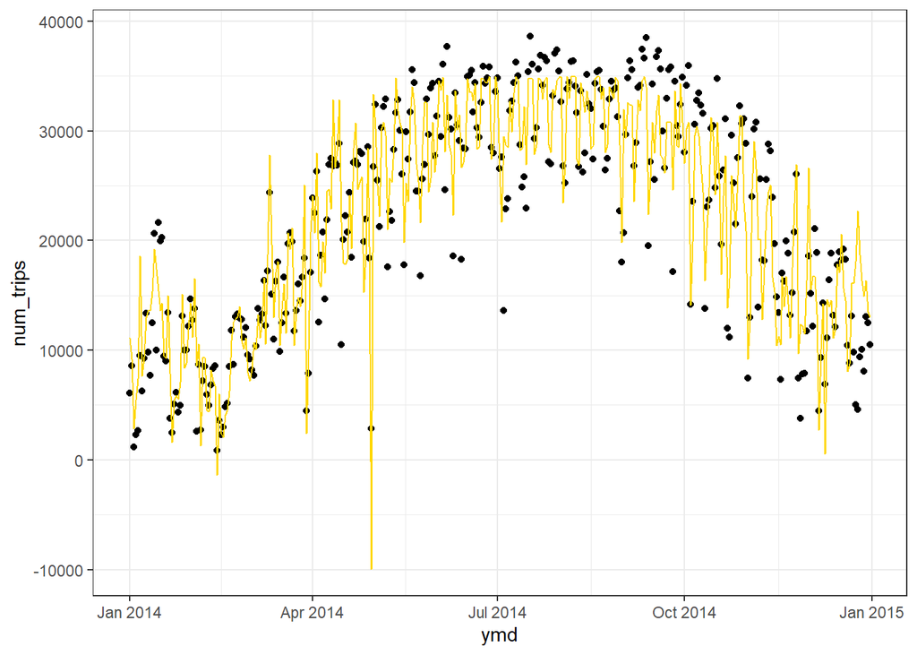

```r
#Plot the final model

#Plot date on x-axis, number of trips on y-axis, actual values as points, and predicted values as line
final_model <- glm(num_trips ~ is_weekend * (poly(tmax, 4) + prcp + snwd + tmax + is_holiday), data = trips_per_day)
trips_per_day |>
    add_predictions(final_model) |>
    ggplot(aes(x=ymd, y=num_trips)) +
    geom_point() +
    geom_line(aes(y=pred), color="gold")
```

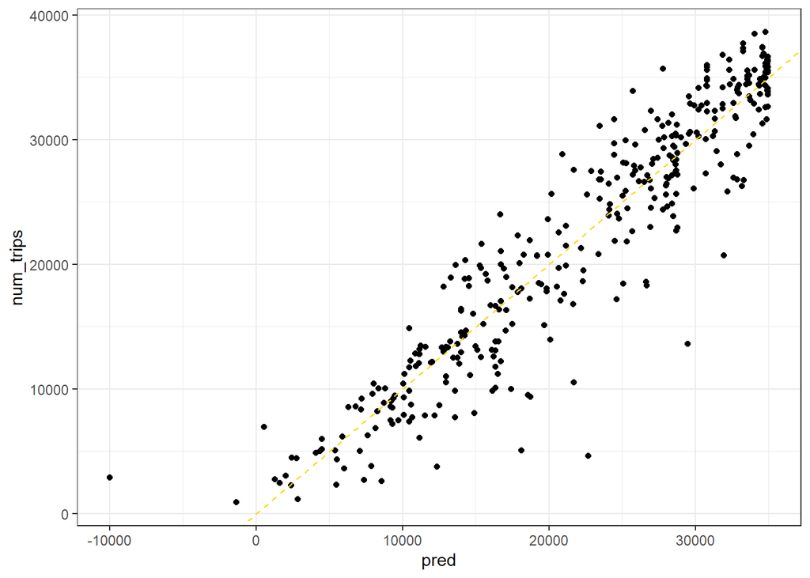

```r
#Plot predicted vs actual values
trips_per_day |>
    add_predictions(final_model) |>
    ggplot(aes(x=pred, y=num_trips)) +
    geom_point() +
    geom_abline(linetype = "dashed", color="gold")
```

Ridership does not increase linearly with heat forever. Instead, it follows a parabolic curve with diminishing returns. Biking activity scales up aggressively as spring transitions into mild summer days, but plateaus or slumps during extreme, oppressive summer heat waves when physical exertion becomes uncomfortable.

```r
#Function to evaluate the final model
evaluate_final_model <- function(model, test_data) {
    # evaluate on the test data
    sqrt(mean((predict(model, test_data) - test_data$num_trips)^2))
}
evaluate_final_model(final_model, trips_per_day_test)
```

```
## [1] 3317.526
```

```r
objects_to_save <- list(
  model = five_var_fourth_poly_model,
  validation_data = trips_per_day_validation
)

# Save the list of objects into an RData file
save(objects_to_save, file = "model_and_data.RData")
```